# Math 534 Assignment 5: EM algorithm

Jose Luis Gonzalez

3/20/2018

### Problem 1

#### A. The EM algorithm for this problem was derived in class. Write an R function that applies the EM algorithm obtained, implementing the following specific instructions: Stop your algorithm when either of the following criteria is satisfied:

- The number of iterations reaches 200
- The modified relative error is less than *tolerr*. The tolerance values should be an input to your program

#### Run your program using the starting value $\theta^{(0)} = 0.02$ and $tolerr = 1e-6$. Your printed output should nicely include the following quantities at iteration n = 1,2,…:

- Iteration number *n* (2 digits, no decimals)
- Value of $\theta^{(n)}$
- Value of the modified relative error (use 1 decimal with exponent notation, e.g. 2.0e-07)

The Code Below uses the EM-algorithm derived in class.

```r
em.gen <- function(theta0,tolerr, rate = FALSE, IT = TRUE){
  y <- c(1997,907, 904,32)
  d_sum <- sum(y[2:4])
  maxit = 200
  values <<- matrix(0, ncol = 3, nrow = maxit,
                   dimnames = list(rep("", maxit), c("IT", "Theta(n)", "MRE")))
  condition = FALSE
  it = 0
  while(it < 200 & condition == FALSE){
  it = it + 1
  x2 = 1997*((theta0/4)/(.5+(theta0/4))) # E-step
  theta1 = (x2 + y[4])/(x2 + d_sum)      # M-step
  mre = abs(theta1 - theta0)/(max(1,abs(theta1)))
  values[it,] <<-c(format(it, digits = 0), formatC(theta1,digits = 12, format = "f"),
                  format(x = mre, scientific = TRUE, digits = 2)) # storing/format

  if(mre < tolerr){
    condition = TRUE
  }
  theta0 = theta1 # Iterative Step
  }
  if( IT == TRUE){
  print(values[1:it,], quote = FALSE) # print steps/values
  }

  # Print Rate of Convergence:
  if(rate == TRUE){
  print(paste('B = 1,',norm(as.numeric(values[it,2])-0.03567466, type = "2")/(
    norm(as.numeric(values[it-1,2])-0.03567466, type ="2"))))
  print(paste('B = 2,',norm(as.numeric(values[it,2])-0.03567466, type = "2")/(
    norm(as.numeric(values[it-1,2])-0.03567466, type ="2")^(2))))
  print(paste('B = 3/2,',norm(as.numeric(values[it,2])-0.03567466, type = "2")/(
    norm(as.numeric(values[it-1,2])-0.03567466, type ="2")^(3/2))))
  }
}
em.gen(.02,10^(-6))
```

```
##  IT Theta(n)       MRE
##  1  0.027793132773 7.8e-03
##  2  0.031742941132 3.9e-03
##  3  0.033721123764 2e-03
##  4  0.034705946241 9.8e-04
##  5  0.035194771667 4.9e-04
##  6  0.035437045211 2.4e-04
##  7  0.035557033560 1.2e-04
##  8  0.035616437341 5.9e-05
##  9  0.035645841640 2.9e-05
##  10 0.035660395186 1.5e-05
##  11 0.035667598091 7.2e-06
##  12 0.035671162906 3.6e-06
##  13 0.035672927162 1.8e-06
##  14 0.035673800302 8.7e-07
```

The exact solution to this problem is $\theta^{*} = (-1657 + \sqrt(3728689))/7680$ = $0.03567466$. Numerically determine whether the EM algorithm is linearly, superlinearly, or quadratically convergent for this problem.

Note for the formula below: - If $0<C<1$ and B = 1, the algorithm converges linearly.

- If $0<C<1$ and B = 2, the algorithm converges quadratically.
- If $C = 0$ and 1< B <2, the algorithm converges super-linearly.

$$\lim_{n\to\infty} \frac{\left|\left| e^{n+1}\right|\right|}{\left|| e^{n}\right||} = C$$

where,

$$e^{n} = x_n - x^{*}$$

For our calculations, we’ll use the true value of theta, the value at the last iterations for $e^{(n+1)}$ and the prior theta for calculating $e^{(n)}$. At the point of convergence, the speed of convergence is

```r
em.gen(.02, 10^(-6), rate = TRUE, IT = FALSE)
```

```
## [1] "B = 1, 0.496121391611294"
## [1] "B = 2, 286305.69713457"
## [1] "B = 3/2, 376.885103033597"
```

If we increase of iterations by increasing the accuracy of MRE we get,

```r
em.gen(.02, 10^(-10), rate = TRUE, IT = FALSE)
```

```
## [1] "B = 1, 0.978679503991574"
## [1] "B = 2, 224364856.624001"
## [1] "B = 3/2, 14818.2754257679"
```

We can see here that the true value of B, is most likely 1, which implies the algorithm converges linearly.

### Problem 2

####A. Plot a density histogram of the data given, superimposed by a Kernal smoother.

```r
data = read.csv("http://mathfaculty.fullerton.edu/mori/Math534/Homework/Chapter%204/ExJ42.txt", header = TRUE)
attach(data)

data_df = data.frame(data)
```

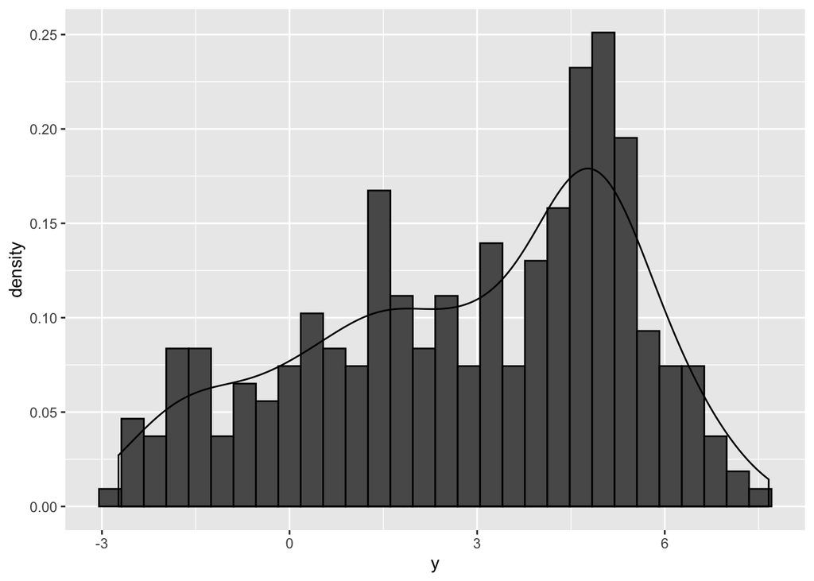

#### B. Suppose that $\mu_1, \mu_2, \mu_3$, and $\sigma^{2}$ are unknown. Derive the Em algorithm for estimating the mixture parameters $\alpha$, and $\beta$ and the parameters

$\mu_1, \mu_2, \mu_3$, and $\sigma^{2}$.

1. Provide initial values for$\alpha, \beta, \mu_1, \mu_2, \mu_3$, and $\sigma^{2}$
2. **E Step**. Calculate our E^{*}(Z_{ij})

$$E^{*}(Z_{ij}) = \frac{\pi_{j}f(y_{i}|\mu_j,\Sigma)}{\sum_{k = 1}^{K}\pi_{k}f(y_{i}|\mu_k,\Sigma)}$$

3. **M step**. Update parameter values using the MLE’s calculated:
   - Note: N = 300, K = 3

$$\hat{\mu_k} = \frac{\sum_{n = 1}^{N} E^{*}(Z_{ik})y_i}{\sum_{n = 1}^{N} E^{*}(Z_{ik})}$$

$$\hat{\sigma} = \frac{\sum_{n = 1}^{N}\sum_{k = 1}^{K} \left[E^{*}(Z_{ik})(y_i-\mu_k)^2 \right] }{\sum_{n = 1}^{N} \sum_{k = 1}^{K}\left[ E^{*}(Z_{ik})\right]}$$

$$\hat{\alpha} = \frac{\sum_{n = 1}^{N} E^{*}(Z_{i1})}{N}$$

$$\hat{\beta} = \frac{\sum_{n = 1}^{N} E^{*}(Z_{i2})}{N}$$

4. Evalulate the MRE to check if parameters met convergence criteria. If the convergence criteria was not met, then use the updated values and return to E step.

$$\text{Relative error} \approx \left|\left|\frac{ \theta^{(n+1)} - \theta^{(n)}}{\text{max}(1,\text{abs}(\theta^{(n+1)}))}\right|\right|$$

#### C. Code the EM algorithm in part (B) as an R function with input variables:

- Data: y = (y_{1},…,y_{n}), an n x 1 vector of data
- Parameter initial values: $\theta = (\alpha, \beta, \mu_1, \mu_2, \mu_3,\sigma^{2})$

```r
theta0 <- matrix(c(1/3,1/3,-2,2,6,1),6,1) # Theta's approx from histogram
y = data$y
em.gauss <- function(y, theta0){
it = 0
condition = FALSE
res <- list()
while(it < 200 & condition == FALSE){
  it = 1 + it
  p = c(theta0[1], theta0[2],(1-theta0[1]-theta0[2]))
  mu1 = theta0[3]; mu2=theta0[4]; mu3=theta0[5];s2=theta0[6]

  f1 = dnorm(y,mean=mu1,sd=sqrt(s2))
  f2 = dnorm(y,mean=mu2,sd=sqrt(s2))
  f3 = dnorm(y,mean=mu3,sd=sqrt(s2))
  N1 = f1*p[1]
  N2 = f2*p[2]
  N3 = f3*p[3]
  D = N1+N2+N3
  Post1 = N1/D # Posterior probability of belonging to group 1
  Post2 = N2/D # Posterior probability of belonging to group 2
  Post3 = N3/D # Posterior probability of belonging to group 3
  Post <<- cbind(Post1,Post2,Post3)
  theta1 <- numeric(6)
  theta1[1:2]=(apply(Post,2,sum)/length(data$y))[1:2]

  theta1[3] <- sum(Post1*y)/sum(Post1)
  theta1[4] <- sum(Post2*y)/sum(Post2)
  theta1[5] <- sum(Post3*y)/sum(Post3)
  theta1[6] <- sum(Post1*(y-mu1)*t(y-mu1) + Post2*(y-mu2)*t(y-mu2) +
                     Post3*(y-mu3)*t(y-mu3))/sum(Post1 + Post2 + Post3)
  mre = norm((theta1-theta0)/pmax(1,abs(theta1)), type = "2")
  if(mre < 10^(-6)){
  condition = TRUE
    }
  values <- cbind(it, t(theta1),mre)
  dimnames(values) <- list("",c("IT", "Alpha","Beta", "Mu1","Mu2","Mu3","Sigma^2", "MRE"))
  res[[it]] <- values
  theta0 = theta1
  }
res
}

a <- em.gauss(y,theta0)
```

| IT | Alpha | Beta | Mu1 | Mu2 | Mu3 | Sigma^2 | MRE |
| --- | --- | --- | --- | --- | --- | --- | --- |
| 1 | 0.1696706 | 0.4120828 | -1.231056 | 2.142406 | 5.173012 | 1.427437 | 0.7367365 |
| 2 | 0.1796142 | 0.3690914 | -1.073349 | 2.089254 | 5.006117 | 1.263665 | 0.2051593 |
| 3 | 0.1902183 | 0.3326898 | -1.011493 | 2.004341 | 4.953239 | 1.141629 | 0.1360620 |
| 58 | 0.1808103 | 0.2954493 | -1.099085 | 1.680808 | 4.849162 | 1.005054 | 0.0000015 |
| 59 | 0.1808101 | 0.2954493 | -1.099086 | 1.680807 | 4.849161 | 1.005054 | 0.0000012 |
| 60 | 0.1808100 | 0.2954494 | -1.099087 | 1.680806 | 4.849161 | 1.005054 | 0.0000010 |

D. Again graph a density histogram of the data, and superimpose the histogram by the three component normal mixture density with parameters obtained as in part h.

```r
x1fit<-seq(-4,4,length=40)
y1fit<-a[[60]][2]*dnorm(x1fit,mean=a[[60]][4],sd=sqrt(a[[60]][7]))

x2fit<-seq(-2,6,length=40)
y2fit<-a[[60]][3]*dnorm(x2fit,mean=a[[60]][5],sd=sqrt(a[[60]][7]))

x3fit<-seq(0,8,length=40)
y3fit<-(1-sum(a[[60]][2:3]))*dnorm(x3fit,mean=a[[60]][6],sd=sqrt(a[[60]][7]))
```

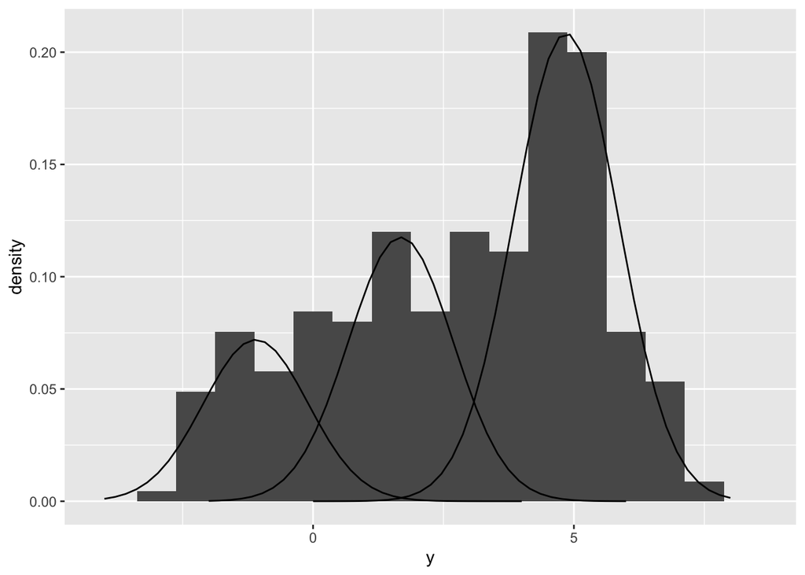

E. For each case use its corresponding posterior probability to determine to which group it is classified. You will compute probabilites of belonging to group 1, 2, or 3 for each case and then assign the case to the group with highest posterior probability. Then show your result graphically as follows: Draw a graph, with the x-axis indicating case number, and the y-axis including the group numbers 1,2, and 3 respectively on the graph. Do you see a pattern, and if so, what does the pattern indicate about the data?

Note: Post was stored into the global envoirnment.

```r
class = numeric(length(data$y))
for(i in 1:length(data$y)){
  class[i] = which(Post[i,] == max(Post[i,]))
}
compare <- cbind(seq(1:300),class)
red <- compare[which(compare[,2]==1)]
green <- compare[which(compare[,2]==2)]
blue <- compare[which(compare[,2]==3)]
```

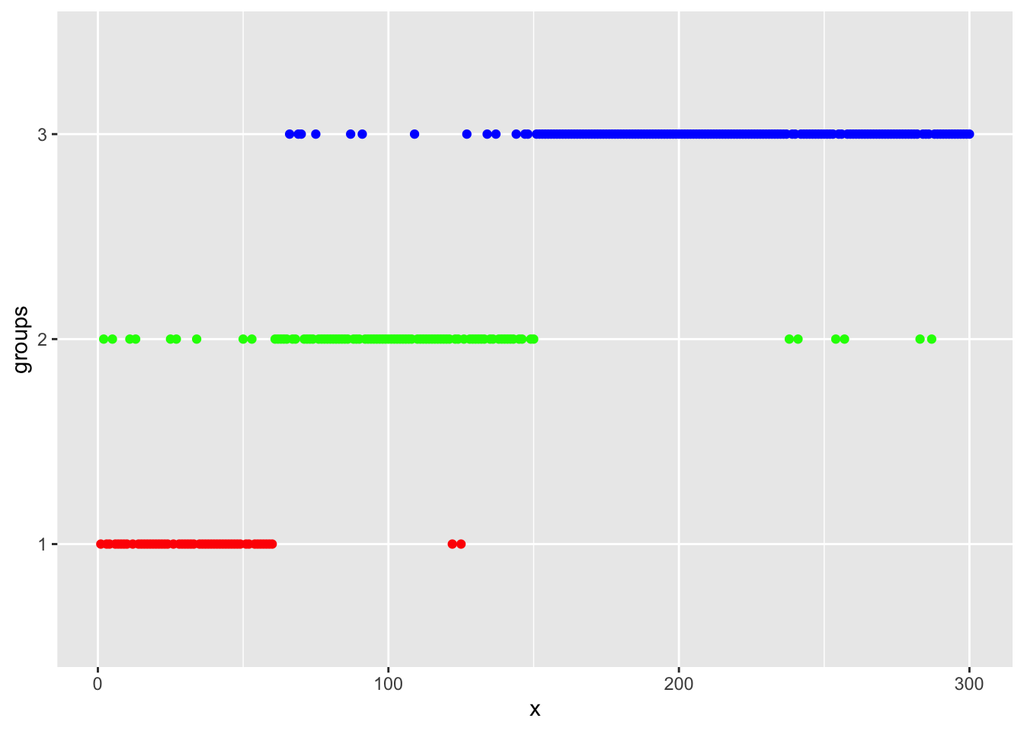